# CS03 - Vaping Behaviors in American Youth

Adrian Castaneda, Garvin Mo Zhen, Melvin Chang

### Load packages

```r
library(tidyverse)
library(tidymodels)
library(broom)
library(OCSdata)
library(viridis)
library(scales)
library(srvyr)
```

## Introduction

In this case study, we seek to analyze tobacco and e-cigarette trends and usage among middle school and high school students (grades 6-12) in the United States. It is without question that the use of tobacco is directly correlated with diseases which may lead to death. It has been known that tobacco is the leading cause of preventable disease and death in the United States (Slide 5, CS03 (Data)). Seeing as how tobacco product usage begins early–during youth and young adulthood–we want to exactly see notable trends in order to minimize tobacco usage in young adults. However, despite declines in tobacco usage, the rise of e-cigarette usage has caused an increase in tobacco product usage among middle school and high school students (Slide 5, CS03 (Data)). Despite not being actual cigarettes, these young adults should still be wary of the health effects associated with e-cigarettes. This includes volatile organic compounds, cancer-causing chemicals, nicotine, ultrafine particles, heavy metals, and flavoring chemicals which are linked to serious lung disease (Slide 6, CS03 (Data)). E-cigarettes are still capable of causing serious lung damage and injury. Analyzing what trends exist for tobacco and e-cigarette usage among middle school and high school students may help to prevent the rising trend of e-cigarette usage and further prevent deadly diseases and lung damage.

## Question

1. How has tobacco and e-cigarette/vaping use by American youths changed since 2015?
2. How does e-cigarette use compare between males and females?
3. What vaping brands and flavors appear to be used the most frequently?
4. Is there a relationship between e-cigarette/vaping use and other tobacco use?
5. How does class level in school change the answer to the above questions?

## The Data

The data we will be using for this case study comes from the National Youth Tobacco Survey (NYTS). The data is an annual survey which asks middle school and high school (grades 6-12) about their tobacco usage in the United States. The data we will be using is from 2015 to 2019.

### Data Import

To begin to answer our questions, we imported our data.

```r
# OCSdata::load_simpler_import("ocs-bp-vaping-case-study", outpath = getwd())
```

### Data Wrangling

The raw data is not exactly in the form we want it, so we begin wrangling the data by reading the csv files into a tibble and assigning appropriate names.

```r
# read CSVs
nyts_data <- list.files("data/simpler_import/",
                        pattern = "*.csv",
                        full.names = TRUE) |>
  map(~ read_csv(.))
# read names from data
nyts_data_names <- list.files("data/simpler_import/",
                              pattern = "*.csv") |>
  str_extract("nyts201[5-9]")
# apply names to tibble/data set
names(nyts_data) <- nyts_data_names
```

There are currently vague column names for the data, so we need to rename each column to be more descriptive. We began with the 2015 data.

```r
nyts_data[["nyts2015"]] <- nyts_data[["nyts2015"]] |>
  # Rename columns for Age, Sex, and Grade
  rename(Age = Qn1,
         Sex = Qn2,
         Grade = Qn3)
```

For the 2016-2018 data, we created a function to rename the columns for us since they all contain similar column names.

```r
update_survey <- function(dataset) {
  dataset |>
    # Rename the following columns to be more descriptive
    rename(Age = Q1,
           Sex = Q2,
           Grade = Q3,
           menthol = Q50A,
           clove_spice = Q50B,
           fruit = Q50C,
           chocolate = Q50D,
           alcoholic_drink = Q50E,
           candy_dessert_sweets = Q50F,
           other = Q50G)
}
```

Now that we have our function, we can apply it to our 2016-2018 data to rename corresponding columns.

```r
nyts_data <- nyts_data |>
  map_at(vars(-nyts2015, -nyts2019), update_survey)
```

The 2019 data is a bit different from the 2015-2018 data, so we need to clean up the column names in a slightly different way but are accomplishing a similar outcome.

```r
nyts_data[["nyts2019"]] <- nyts_data[["nyts2019"]] |>
  rename(brand_ecig = Q40,
         Age = Q1,
         Sex = Q2,
         Grade = Q3,
         menthol = Q62A,
         clove_spice = Q62B,
         fruit = Q62C,
         chocolate = Q62D,
         alcoholic_drink = Q62E,
         candy_dessert_sweets = Q62F,
         other = Q62G)
```

Now the names of our columns are more descriptive to what they represent.

```r
map(nyts_data, names)
```

```
## $nyts2015
##  [1] "psu"        "finwgt"     "stratum"    "Age"        "Sex"
##  [6] "Grade"      "ECIGT"      "ECIGAR"     "ESLT"       "EELCIGT"
## [11] "EROLLCIGTS" "EFLAVCIGTS" "EBIDIS"     "EFLAVCIGAR" "EHOOKAH"
## [16] "EPIPE"      "ESNUS"      "EDISSOLV"   "CCIGT"      "CCIGAR"
## [21] "CSLT"       "CELCIGT"    "CROLLCIGTS" "CFLAVCIGTS" "CBIDIS"
## [26] "CHOOKAH"    "CPIPE"      "CSNUS"      "CDISSOLV"
##
## $nyts2016
##  [1] "psu"                  "finwgt"               "stratum"
##  [4] "Age"                  "Sex"                  "Grade"
##  [7] "ECIGT"                "ECIGAR"               "ESLT"
## [10] "EELCIGT"              "EHOOKAH"              "EROLLCIGTS"
## [13] "EFLAVCIGAR"           "EPIPE"                "ESNUS"
## [16] "EDISSOLV"             "EBIDIS"               "CCIGT"
```

[output cut: 46 more lines]

Knowing that in the raw data an age value of 1 corresponds to 9 years old and a grade value of 1 corresponds to 6th grade, we made adjustments to the values so 1 = 1, 2 = 2, across the columns in the data set. We also made values more descriptive by converting to male/female values for sex, identifying NAs, converting appropriate values to true/false, and better categorizing ages >18 and grades not 1-12.

```r
update_values <- function(dataset){
  dataset |>
    mutate(Age = as.numeric(Age) + 8, # Add 8 to the age so 9 = 9 years old
           Grade = as.numeric(Grade) + 5) |> # Add 5 to the grade so 6 = 6th grade
    # Convert everything to factors
    mutate(Age = as.factor(Age),
           Grade = as.factor(Grade),
           Sex = as.factor(Sex)) |>
    # Convert 1 and 2s to male and females
    mutate(Sex = recode(Sex,
                        `1` = "male",
                        `2` = "female")) |>
    mutate_all(~ replace(., . %in% c("*", "**"), NA)) |> # Identify and assign NA values
    mutate(Age = recode(Age, `19` = ">18"), # Change 19 to >=18 for age
           Grade = recode(Grade,
                          `13` = "Ungraded/Other")) |> # Convert 13 to ungraded/other to better describe people not in 1-12th grade
    # Convert data values to logical instead of 1 and 2s
    mutate_at(vars(starts_with("E", ignore.case = FALSE),
                   starts_with("C", ignore.case = FALSE)
    ), list( ~ recode(., `1` = TRUE,
                      `2` = FALSE,
                      .default = NA,
                      .missing = NA)))
}
```

Apply our function to the data.

```r
nyts_data <- map(nyts_data, update_values)
```

For the flavor data in 2016-2019, we decided to convert missing values to FALSE since we only care about the observation that say TRUE. We did this by creating a function and applying it to the four years of data.

```r
update_flavors <- function(dataset){
  dataset |>
    mutate_at(vars(menthol:other),
              list(~ recode(.,
                            `1` = TRUE,
                            .default = FALSE,
                            .missing = FALSE))) }
nyts_data  <- nyts_data  |>
  map_at(vars(-nyts2015), update_flavors)
```

For the 2019 data, we have numbers corresponding to e-cigarrete brands, which we reassigned to a string of the e-cigarrete brand to make the data easier to interpret. We also reassigned all values corresponding to missing values to NA.

```r
nyts_data[["nyts2019"]] <- nyts_data[["nyts2019"]] |>
  mutate_all(~ replace(., . %in% c(".N", ".S", ".Z"), NA)) |> # Assign missing values to NA
  mutate(psu = as.character(psu)) |> # Convert to characters
  # Replace value with corresponding brand name.
  mutate(brand_ecig = recode(brand_ecig,
                             `1` = "Other", # levels 1,8 combined to `Other`
                             `2` = "Blu",
                             `3` = "JUUL",
                             `4` = "Logic",
                             `5` = "MarkTen",
                             `6` = "NJOY",
                             `7` = "Vuse",
                             `8` = "Other"))
```

Now that we have most of our data cleaned, we combined each year of data all into one data set.

```r
nyts_data <- nyts_data |>
  map_df(bind_rows, .id = "year") |>
  mutate(year = as.numeric(str_remove(year, "nyts"))) # remove "nyts" from year column
```

We have several columns on whether an individual has used a certain form of tobacco. To determine whether an individual has used any type of tobacco, we summed all the TRUEs in our data for tobacco and if that sum is greater than 0 then we know that person has used tobacco. We did this to determine if someone has ever used tobacco and if someone is currently using tobacco.

```r
nyts_data <- nyts_data %>%
  # Sum all TRUEs for ever and current
  mutate(tobacco_sum_ever = rowSums(select(., starts_with("E",
                                    ignore.case = FALSE)), na.rm = TRUE),
         tobacco_sum_current = rowSums(select(., starts_with("C",
                                    ignore.case = FALSE)), na.rm = TRUE))  |>
  # if that sum is greater than 0 assign TRUE, if not then FALSE
  mutate(tobacco_ever = case_when(tobacco_sum_ever > 0 ~ TRUE,
                                  tobacco_sum_ever == 0 ~ FALSE),
         tobacco_current = case_when(tobacco_sum_current > 0 ~ TRUE,
                                     tobacco_sum_current == 0 ~ FALSE))
```

Similar to what we did with tobacco, we used a similar method to determine if someone has used e-cigarretes and non e-cigarretes ever or currently.

```r
nyts_data <- nyts_data %>%
  # Sum all TRUEs for ever and current for e-cigs and non e-cigs
  mutate(ecig_sum_ever = rowSums(select(., EELCIGT), na.rm = TRUE),
         ecig_sum_current = rowSums(select(., CELCIGT), na.rm = TRUE),
         non_ecig_sum_ever = rowSums(select(., starts_with("E",  ignore.case = FALSE),
                                            -EELCIGT), na.rm = TRUE),
         non_ecig_sum_current = rowSums(select(., starts_with("C", ignore.case = FALSE),
                                               -CELCIGT), na.rm = TRUE)) |>
  # if that sum is greater than 0 assign TRUE, if not then FALSE
  mutate(ecig_ever = case_when(ecig_sum_ever > 0 ~ TRUE,
                              ecig_sum_ever == 0 ~ FALSE),
         ecig_current = case_when(ecig_sum_current > 0 ~ TRUE,
                                  ecig_sum_current == 0 ~ FALSE),
         non_ecig_ever = case_when(non_ecig_sum_ever > 0 ~ TRUE,
                                   non_ecig_sum_ever == 0 ~ FALSE),
         non_ecig_current = case_when(non_ecig_sum_current > 0 ~ TRUE,
                                      non_ecig_sum_current == 0 ~ FALSE))
```

Furthermore, we grouped everyone into only e-cigarette users, only non e-cigarette users, neither, or combination of products.

```r
# Determine if someone has only used e-cigs, only non e-cigs, neither, or both
nyts_data <- nyts_data |>
             mutate(ecig_only_ever = case_when(ecig_ever == TRUE &
                                           non_ecig_ever == FALSE &
                                            ecig_current == FALSE &
                                        non_ecig_current == FALSE ~ TRUE,
                                                             TRUE ~ FALSE),
              ecig_only_current = case_when(ecig_current == TRUE &
                                           non_ecig_ever == FALSE &
                                        non_ecig_current == FALSE ~ TRUE,
                                                            TRUE ~ FALSE),
            non_ecig_only_ever = case_when(non_ecig_ever == TRUE &
                                               ecig_ever == FALSE &
                                            ecig_current == FALSE &
                                        non_ecig_current == FALSE ~ TRUE,
                                                            TRUE ~ FALSE),
      non_ecig_only_current = case_when(non_ecig_current == TRUE &
                                               ecig_ever == FALSE &
                                            ecig_current == FALSE ~ TRUE,
                                                            TRUE ~ FALSE),
                        no_use = case_when(non_ecig_ever == FALSE &
                                               ecig_ever == FALSE &
                                            ecig_current == FALSE &
                                        non_ecig_current == FALSE ~ TRUE,
                                                            TRUE ~ FALSE)) %>%
                 mutate(Group = case_when(ecig_only_ever == TRUE |
                                       ecig_only_current == TRUE ~ "Only e-cigarettes",
                                      non_ecig_only_ever == TRUE |
                                   non_ecig_only_current == TRUE ~ "Only other products",
                                                  no_use == TRUE ~ "Neither",
                                          ecig_only_ever == FALSE &
                                       ecig_only_current == FALSE &
                                      non_ecig_only_ever == FALSE &
                                   non_ecig_only_current == FALSE &
                                                  no_use == FALSE ~ "Combination of products"))
```

To extend our analysis, we wanted to analyze differences in students in different class levels o we added a column to specify their class level.

```r
nyts_data <- nyts_data |>
  mutate(level = case_when(Grade == 6 ~ "Middle School",
                           Grade == 7 ~ "Middle School",
                           Grade == 8 ~ "Middle School",
                           Grade == 9 ~ "High School",
                           Grade == 10 ~ "High School",
                           Grade == 11 ~ "High School",
                           Grade == 12 ~ "High School",
                           Grade == "Ungraded/Other" ~ "Ungraded/Other"))
```

We added a count for total of number of students each year.

```r
nyts_data <- nyts_data |>
  add_count(year)
```

Finally, we can save our data.

```r
save(nyts_data, file="data/wrangled/wrangled_data_vaping.rda")
```

And we have our wrangled data set.

```r
nyts_data
```

```
## # A tibble: 95,465 × 60
##     year psu    finwgt stratum Age   Sex    Grade ECIGT ECIGAR ESLT  EELCIGT
##    <dbl> <chr>   <dbl> <chr>   <fct> <fct>  <fct> <lgl> <lgl>  <lgl> <lgl>
##  1  2015 015438   217. BR3     18    female 12    FALSE TRUE   FALSE FALSE
##  2  2015 015438   325. BR3     17    male   12    TRUE  TRUE   FALSE TRUE
##  3  2015 015438   325. BR3     18    male   12    FALSE FALSE  FALSE FALSE
##  4  2015 015438   397. BR3     18    male   12    TRUE  FALSE  FALSE TRUE
##  5  2015 015438   265. BR3     18    female 12    FALSE FALSE  FALSE FALSE
##  6  2015 015438   265. BR3     18    female 12    TRUE  FALSE  FALSE TRUE
##  7  2015 015438   397. BR3     18    male   12    TRUE  TRUE   TRUE  TRUE
##  8  2015 015438   265. BR3     18    female 12    TRUE  FALSE  TRUE  TRUE
##  9  2015 015438   325. BR3     18    male   12    FALSE FALSE  FALSE FALSE
## 10  2015 015438   217. BR3     18    female 12    FALSE FALSE  FALSE FALSE
## # … with 95,455 more rows, and 49 more variables: EROLLCIGTS <lgl>,
## #   EFLAVCIGTS <lgl>, EBIDIS <lgl>, EFLAVCIGAR <lgl>, EHOOKAH <lgl>,
## #   EPIPE <lgl>, ESNUS <lgl>, EDISSOLV <lgl>, CCIGT <lgl>, CCIGAR <lgl>,
## #   CSLT <lgl>, CELCIGT <lgl>, CROLLCIGTS <lgl>, CFLAVCIGTS <lgl>,
## #   CBIDIS <lgl>, CHOOKAH <lgl>, CPIPE <lgl>, CSNUS <lgl>, CDISSOLV <lgl>,
## #   menthol <lgl>, clove_spice <lgl>, fruit <lgl>, chocolate <lgl>,
## #   alcoholic_drink <lgl>, candy_dessert_sweets <lgl>, other <lgl>, EHTP <lgl>,
## #   CHTP <lgl>, brand_ecig <chr>, tobacco_sum_ever <dbl>,
## #   tobacco_sum_current <dbl>, tobacco_ever <lgl>, tobacco_current <lgl>,
## #   ecig_sum_ever <dbl>, ecig_sum_current <dbl>, non_ecig_sum_ever <dbl>,
## #   non_ecig_sum_current <dbl>, ecig_ever <lgl>, ecig_current <lgl>,
## #   non_ecig_ever <lgl>, non_ecig_current <lgl>, ecig_only_ever <lgl>,
## #   ecig_only_current <lgl>, non_ecig_only_ever <lgl>,
## #   non_ecig_only_current <lgl>, no_use <lgl>, Group <chr>, level <chr>,
## #   n <int>
```

## Analysis

### Exploratory Data Analysis

To begin answering how tobacco and e-cigarette usage has changed since 2015, we can examine trends for both tobacco and e-cigarettes individually.

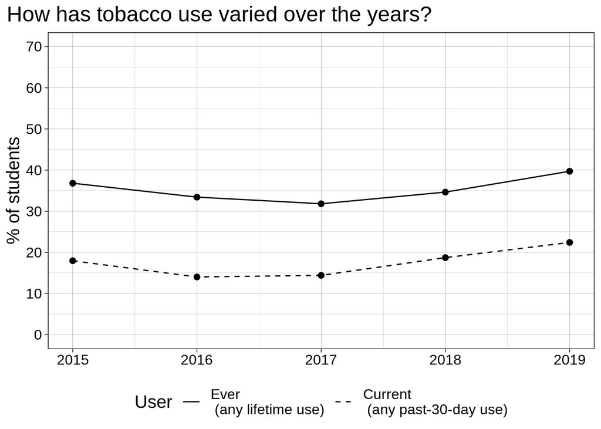

```r
nyts_data |>
  group_by(year) |>
  summarize("Ever \n (any lifetime use)" = (mean(tobacco_ever, na.rm = TRUE) * 100),
            "Current \n (any past-30-day use)" = (mean(tobacco_current, na.rm = TRUE) * 100)) |>
  pivot_longer(cols = -year, names_to = "User", values_to = "Percentage of students") |>
  ggplot(aes(x = year, y = `Percentage of students`)) +
  geom_line(aes(linetype = User)) +
  geom_point(show.legend = FALSE, size = 2) +
  # this allows us to choose what type of line we want for each line
  scale_linetype_manual(values = c(1, 2),
                        breaks = c("Ever \n (any lifetime use)",
                                   "Current \n (any past-30-day use)")) +
  # this allows us to specify how the y-axis should appear
  scale_y_continuous(breaks = seq(0, 70, by = 10),
                     labels = seq(0, 70, by = 10),
                     limits = c(0, 70)) +
  # this adjusts the background style of the plot
  theme_linedraw() +
  labs(title = "How has tobacco use varied over the years?",
       y = "% of students") +
  # this moves the legend to the bottom of the plot and removes the x axis title
  theme(legend.position = "bottom",
        axis.title.x = element_blank(),
        text = element_text(size = 15),
        plot.title.position = "plot")
```

As we can see from the graph, tobacco use was on a decline from 2015 to 2017, and since 2017, tobacco usage has been slowly increasing. In 2015, tobacco usage among students within their lifetime makes up approximately 36% of students. This decreases as low as approximately 31% in 2017. This percentage has slowly been increasing with approximately 40% of students having used tobacco in their lifetime in 2019.

Students who have used tobacco recently (any over the past 30 days) have followed a similar trend. The percentage of students who currently use tobacco is approximately 19% in 2015, which slowly declines to approximately 15% of students in 2016 and 2017. Since 2017, this number has increased to approximately 23% in 2019.

Next, we will examine trends for e-cigarette usage since 2015.

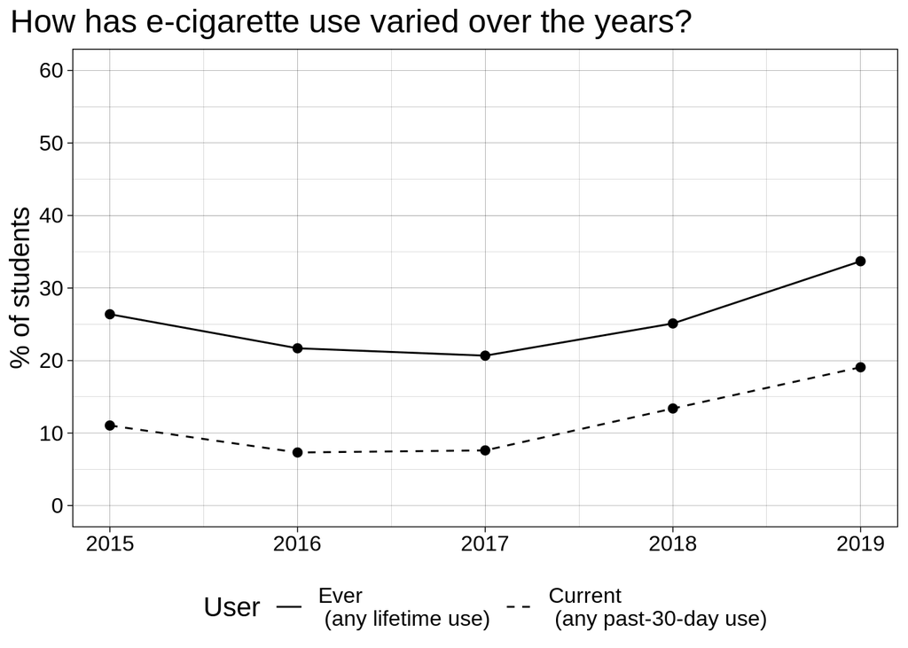

```r
nyts_data |>
  group_by(year) |>
  summarize("Ever \n (any lifetime use)" = (mean(ecig_ever, na.rm = TRUE) * 100),
            "Current \n (any past-30-day use)" = (mean(ecig_current, na.rm = TRUE) * 100)) |>
  pivot_longer(cols = -year, names_to = "User", values_to = "Percentage of students") |>
  ggplot(aes(x = year, y = `Percentage of students`)) +
  geom_line(aes(linetype = User)) +
  geom_point(show.legend = FALSE, size = 2) +
  # this allows us to choose what type of line we want for each line
  scale_linetype_manual(values = c(1, 2),
                        breaks = c("Ever \n (any lifetime use)",
                                   "Current \n (any past-30-day use)")) +
  # this allows us to specify how the y-axis should appear
  scale_y_continuous(breaks = seq(0, 60, by = 10),
                     labels = seq(0, 60, by = 10),
                     limits = c(0, 60)) +
  # this adjusts the background style of the plot
  theme_linedraw() +
  labs(title = "How has e-cigarette use varied over the years?",
       y = "% of students") +
  # this moves the legend to the bottom of the plot and removes the x axis title
  theme(legend.position = "bottom",
        axis.title.x = element_blank(),
        text = element_text(size = 15),
        plot.title.position = "plot")
```

We can see from the graph that e-cigarette usage shares a similar trend to that of tobacco usage. In 2015, about 26% of students have used e-cigarettes in their lifetime which slowly decreases to 21% in 2017. Since 2017, this percentage has risen to about 34% of students.

For students who have used e-cigarettes over the past 30 days, we see this this makes up about 11% of students in 2015. This percentage declines to about 7% of students in 2016 and 2017, which then significantly increases to about 19% of students by 2019.

In our third graph, we can examine what percentage of students have not used any of these products, which have used both, which have used only e-cigarettes, and which have used only other products.

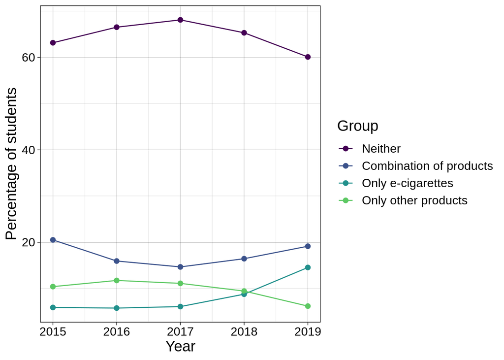

```r
v_colors =  viridis(5)[1:4]  #specify color palatte
nyts_data |>
  group_by(Group, year, n) |>
  summarize(group_count = n()) |>
  mutate("Percentage of students" = group_count / n * 100) |>
  ggplot(aes(x = year, y = `Percentage of students`, color = Group)) +
  geom_point(size = 2) +
  geom_line() +
  scale_color_manual(breaks = c("Neither", "Combination of products",
                                "Only e-cigarettes", "Only other products"),
                     values = v_colors) +
  theme_linedraw() +
  labs(x = "Year") +
  theme(text = element_text(size = 15),
        plot.title.position = "plot")
```

From examining these graphs, we notice how e-cigarettes have grown in popularity compared to tobacco usage. Although a larger percentage of students use both tobacco and e-cigarette products, it would be no surprise if students would begin to make this switch to solely use e-cigarettes given these trends.

After exploring the significant differences between tobacco and e-cigarette use within the past years. We will continue to explore whether sex would make a difference in tobacco and e-cigarette use. First we will plot e-cigarette use between Sex.

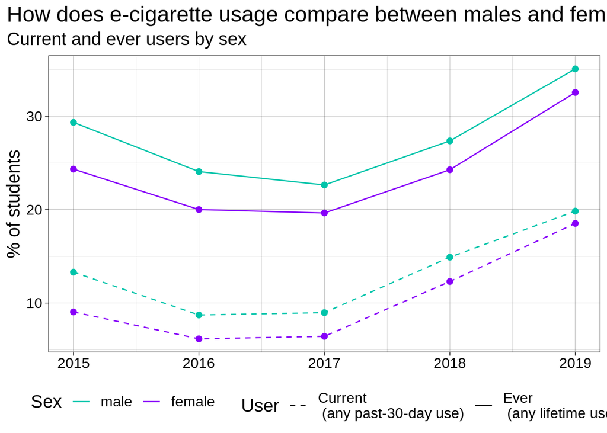

```r
#question 2
v_colors =  v_colors =  c("#00c4aa", "#8700f9") #getting desired colors

nyts_data |>
  filter(!is.na(Sex)) |> # getting all rows that have inputs in the Sex column
  group_by(year, Sex) |> # combine rows that have the same year and Sex
  # Gettign the percentage of current/ever students that have used e-cigarretes
  summarize("Ever \n (any lifetime use)" = (mean(EELCIGT, na.rm = TRUE) * 100),
            "Current \n (any past-30-day use)" = (mean(CELCIGT, na.rm = TRUE) * 100)) |>
  pivot_longer(cols = "Ever \n (any lifetime use)":"Current \n (any past-30-day use)",
               names_to = "User",
               values_to = "Percentage of students") |>
  # plotting percent of students that use e-cigarettes separated by Sex
  ggplot(aes(x = year, y = `Percentage of students`, color = Sex)) +
  geom_line(aes(linetype = User)) + # setting the type of line for each category
  geom_point(show.legend = FALSE, size = 2) +
  scale_linetype_manual(values = c(2, 1)) +
  scale_color_manual(values = v_colors) + # setting the colors
  theme_linedraw() +
  # setting title and axis
  labs(title = "How does e-cigarette usage compare between males and females?",
       subtitle = "Current and ever users by sex",
       y = "% of students") +
  # adding legend
  theme(legend.position = "bottom",
        axis.title.x = element_blank(),
        text = element_text(size = 15),
        plot.title.position = "plot")
```

We can see that from the years 2015-2017 there was a small decline in current and ever e-cigarette users. However, after the year 2017, e-cigarette usage began to pick up reaching to over 30% usage in both male and female students in terms of any lifetime use. Overall, there is an obvious trend that a larger percentage of male students use e-cigarettes in comparison to female students.

Now we will plot the differences in tobacco usage in Sex.

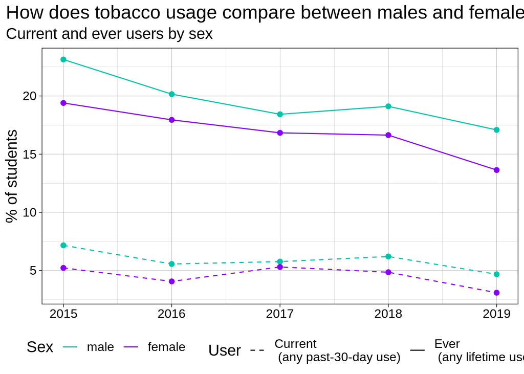

```r
nyts_data |>
  filter(!is.na(Sex)) |> # getting all rows that have inputs in the Sex column
  group_by(year, Sex) |> # combine rows that have the same year and Sex
  # Gettign the percentage of current/ever students that have used e-cigarretes
  summarize("Ever \n (any lifetime use)" = (mean(ECIGT, na.rm = TRUE) * 100),
            "Current \n (any past-30-day use)" = (mean(CCIGT, na.rm = TRUE) * 100)) |>
  pivot_longer(cols = "Ever \n (any lifetime use)":"Current \n (any past-30-day use)",
               names_to = "User",
               values_to = "Percentage of students") |>
  # plotting percent of students that use e-cigarettes separated by Sex
  ggplot(aes(x = year, y = `Percentage of students`, color = Sex)) +
  geom_line(aes(linetype = User)) + # setting the type of line for each category
  geom_point(show.legend = FALSE, size = 2) +
  scale_linetype_manual(values = c(2, 1)) +
  scale_color_manual(values = v_colors) + # setting the colors
  theme_linedraw() +
  # setting title and axis
  labs(title = "How does tobacco usage compare between males and females?",
       subtitle = "Current and ever users by sex",
       y = "% of students") +
  # adding legend
  theme(legend.position = "bottom",
        axis.title.x = element_blank(),
        text = element_text(size = 15),
        plot.title.position = "plot")
```

To continue visualizing the key differences in male and female students, we will also create a function to plot for specific grade level, in other words, the differences in middle school and high school students.

```r
#function to plot each of the Sex by level
plot_level <- function(lvl) {
  nyts_data |>
  filter(!is.na(Sex)) |> # getting all rows that have inputs in the Sex column
  filter(level == lvl) |>
  group_by(year, Sex) |> # combine rows that have the same year and Sex
  # Gettign the percentage of current/ever students that have used e-cigarretes
  summarize("Ever \n (any lifetime use)" = (mean(EELCIGT, na.rm = TRUE) * 100),
            "Current \n (any past-30-day use)" = (mean(CELCIGT, na.rm = TRUE) * 100)) |>
  pivot_longer(cols = "Ever \n (any lifetime use)":"Current \n (any past-30-day use)",
               names_to = "User",
               values_to = "Percentage of students") |>
  # plotting percent of students that use tobacco separated by Sex
  ggplot(aes(x = year, y = `Percentage of students`, color = Sex)) +
  geom_line(aes(linetype = User)) + # setting the type of line for each category
  geom_point(show.legend = FALSE, size = 2) +
  scale_linetype_manual(values = c(2, 1)) +
  scale_color_manual(values = v_colors) + # setting the colors
  theme_linedraw() +
  # setting title and axis
  labs(title = "How does e-cigarette usage compare between males and females?",
       subtitle = paste("Current and ever users by sex in", lvl, sep=" "),
       y = "% of students") +
  # adding legend
  theme(legend.position = "bottom",
        axis.title.x = element_blank(),
        text = element_text(size = 15),
        plot.title.position = "plot")
}
```

To add on to the previous plot, we will also check whether there significant differences in the grade level that the students are in that would indicate e-cigarette use. We will look at e-cigarette use specifically since it become a trend amongst students.

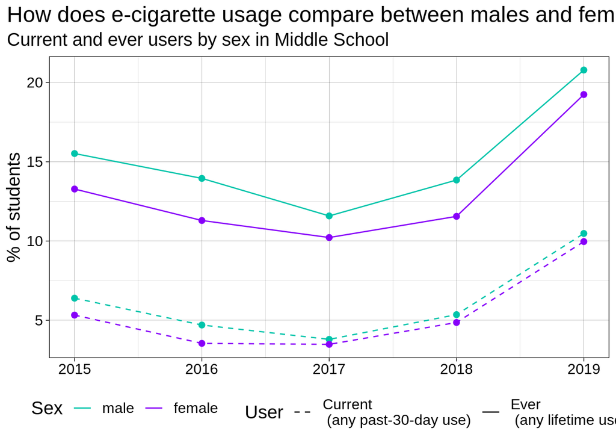

```r
plot_level("Middle School")
```

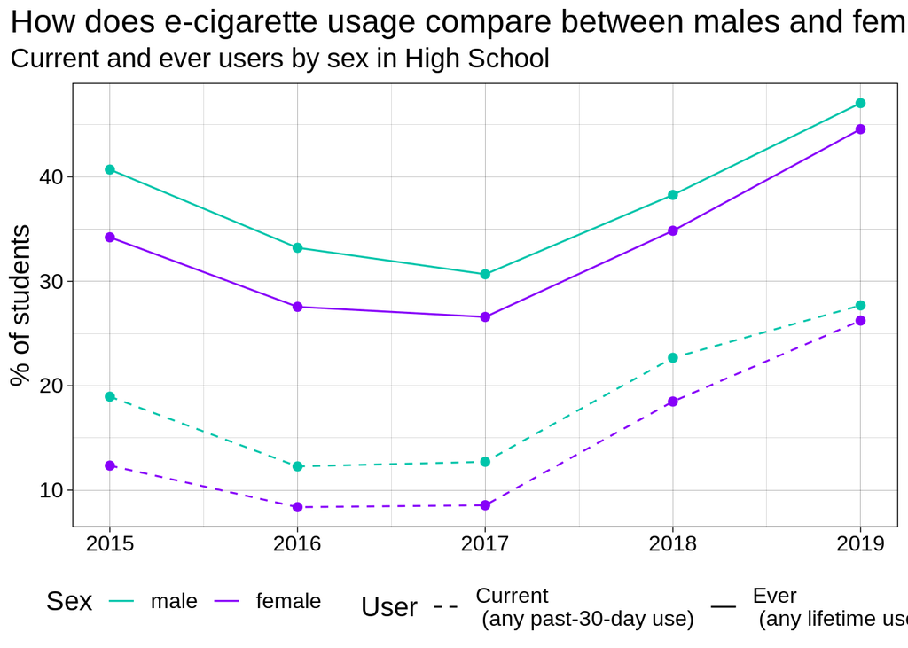

```r
plot_level("High School")
```

Among middle school students, within the past 30 days, we can see that the gap between male and female students was almost close to none. We can also visualize that in lifetime use, high school students double the usage compared to middle school students. Overall, the trend continues where a larger portion of male students use e-cigarettes compared to female students in both middle school and high school.

To begin to explore what vaping brands and flavors appear to be used the most frequently, we plotted percent of e-cigarette users by brand.

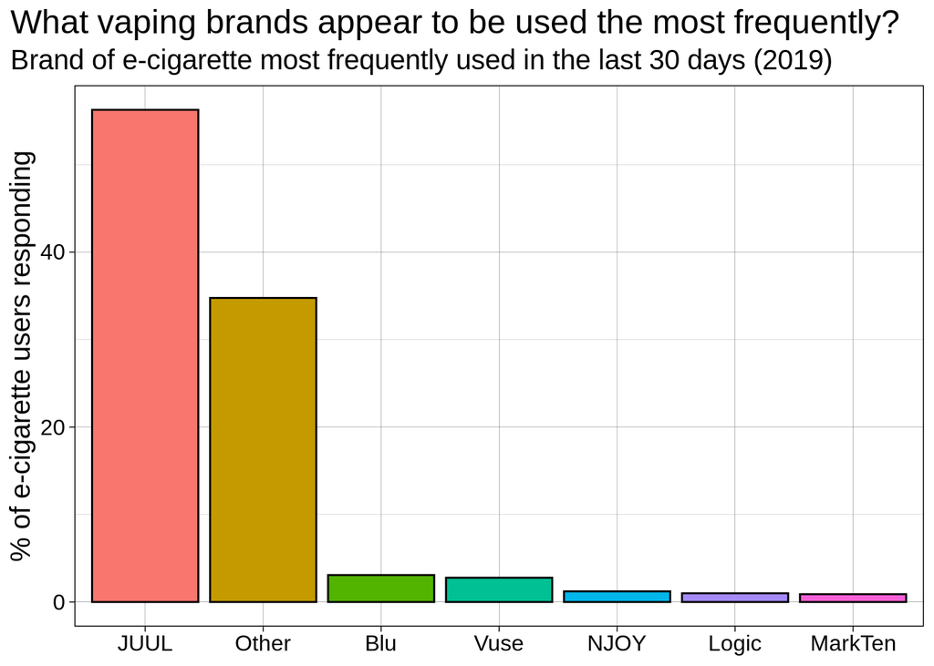

```r
nyts_data |>
  filter(year == 2019) |> # Filter to 2019 data
  group_by(brand_ecig) |> # Group by brand
  filter(!is.na(brand_ecig)) |> # Remove NA
  summarize(n = n()) |> # Count number of observation in a brand
  # Convert count to a percentage
  mutate(total = sum(n),
         Percent = n * 100 / total) |>
  mutate(brand_ecig = fct_reorder(brand_ecig, desc(Percent))) |> # Reorder
  # Plot % of e-cigarrete users by brand
  ggplot(aes(x = brand_ecig, y = Percent, fill = brand_ecig)) +
  geom_bar(stat = "identity", color = "black") +
  theme_linedraw() +
  # Set labels
  labs(title = "What vaping brands appear to be used the most frequently?",
       subtitle = "Brand of e-cigarette most frequently used in the last 30 days (2019)",
       y = "% of e-cigarette users responding") +
  # Set theme
  theme(legend.position = "none",
        axis.title.x = element_blank(),
        text = element_text(size = 15),
        plot.title.position = "plot")
```

From this chart we see that JUUL by far is the most popular brand in our data set with over 50% of e-cigarrete users choosing JUUL. The next most popular brand, Blu, sits at less than 5%. The other category is fairly large at around 35% further indicating that no other brand is popular besides JUUL.

Since our data set span multiple levels of schooling, we wanted to see if the most popular e-cigarette brands changed with class level.

```r
Middle_School = nyts_data |>
  filter(year == 2019, level == "Middle School") |> # Filter to 2019 data and middle schoolers
  group_by(brand_ecig) |> # Group by brand
  filter(!is.na(brand_ecig)) |> # Remove NA
  summarize(n = n()) |> # Count number of observation in a brand
  # Convert count to a percentage
  mutate(total = sum(n),
         Percent = n * 100 / total) |>
  mutate(brand_ecig = fct_reorder(brand_ecig, desc(Percent))) |> # Reorder
  # Plot % of e-cigarrete users by brand
  ggplot(aes(x = brand_ecig, y = Percent, fill = brand_ecig)) +
  geom_bar(stat = "identity", color = "black") +
  theme_linedraw() +
  # Set labels
  labs(title = "What vaping brands appear to be used the most frequently by Middle School Students?",
       subtitle = "Brand of e-cigarette most frequently used in the last 30 days (2019)",
       y = "% of e-cigarette users responding") +
  # Set theme
  theme(legend.position = "none",
        axis.title.x = element_blank(),
        text = element_text(size = 15),
        plot.title.position = "plot")

High_School = nyts_data |>
  filter(year == 2019, level == "High School") |> # Filter to 2019 data and high schoolers
  group_by(brand_ecig) |> # Group by brand
  filter(!is.na(brand_ecig)) |> # Remove NA
  summarize(n = n()) |> # Count number of observation in a brand
  # Convert count to a percentage
  mutate(total = sum(n),
         Percent = n * 100 / total) |>
  mutate(brand_ecig = fct_reorder(brand_ecig, desc(Percent))) |> # Reorder
  # Plot % of e-cigarrete users by brand
  ggplot(aes(x = brand_ecig, y = Percent, fill = brand_ecig)) +
  geom_bar(stat = "identity", color = "black") +
  theme_linedraw() +
  # Set labels
  labs(title = "What vaping brands appear to be used the most frequently by High School Students?",
       subtitle = "Brand of e-cigarette most frequently used in the last 30 days (2019)",
       y = "% of e-cigarette users responding") +
  # Set theme
  theme(legend.position = "none",
        axis.title.x = element_blank(),
        text = element_text(size = 15),
        plot.title.position = "plot")
```

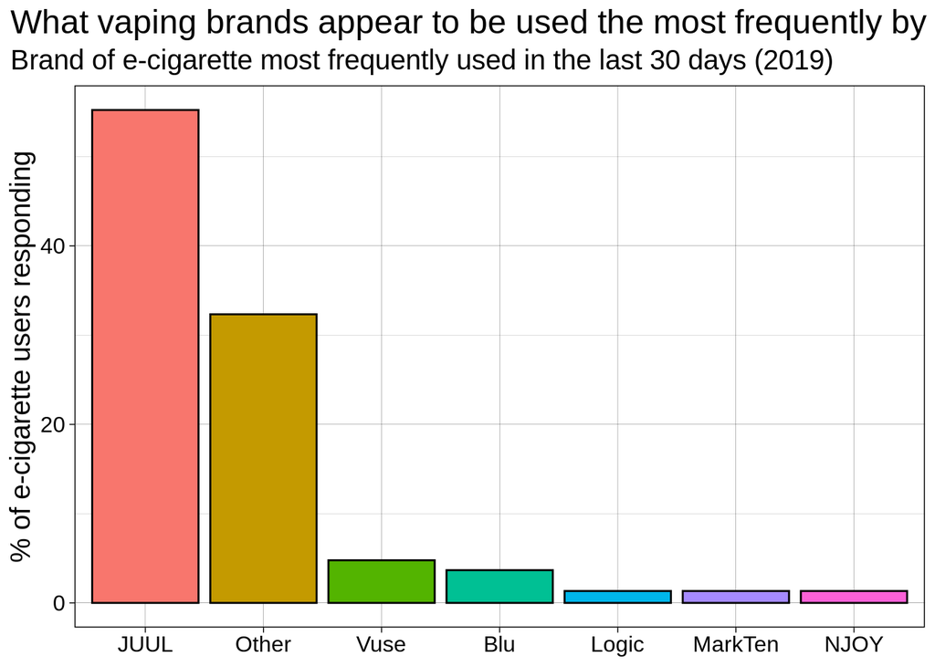

```r
Middle_School
```

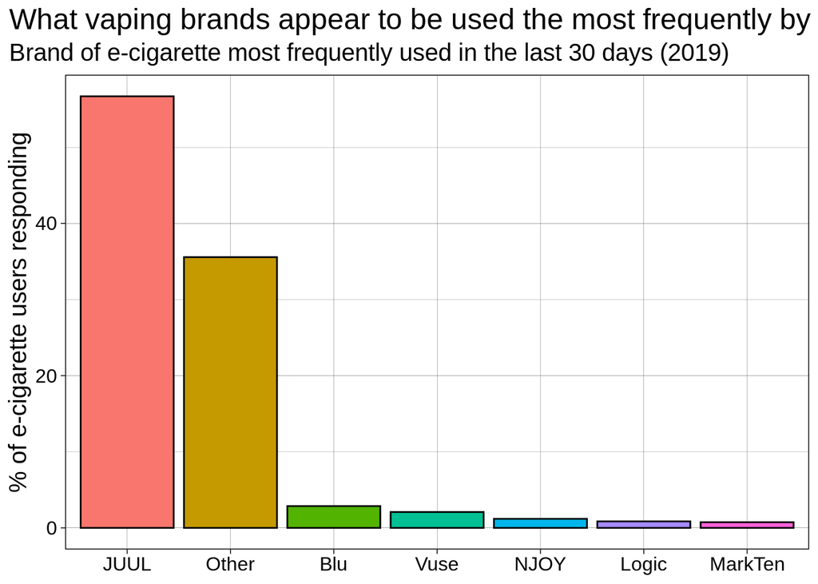

```r
High_School
```

In this case, there seems to be minor differences in cigarette brand popularity between middle and high school students. High school students prefer JUUL slightly more and middle school students prefer Vuse slightly more than Blu. All changes are minor nonetheless but there are slight differences.

Although e-cigarettes are marketed as a better alternative to cigarettes, we wanted to see if there is a relationship between e-cigarette and cigarette use.

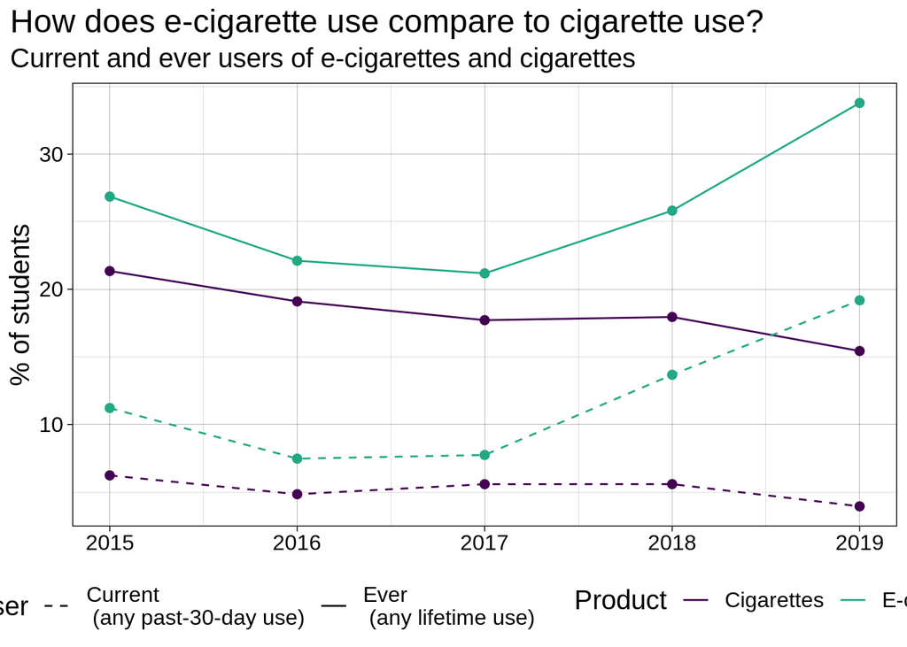

```r
# Set desired colors
v_colors =  viridis(6)[c(1, 4)]
nyts_data |>
  group_by(year) |> # Group data by year
  # Determine what percent of students have ever and currently use tobacco and e-cigarettes
  summarize(
    "Cigarettes, Ever \n (any lifetime use)" = (mean(ECIGT, na.rm = TRUE) * 100),
    "E-cigarettes, Ever \n (any lifetime use)" = (mean(EELCIGT, na.rm = TRUE) * 100),
    "Cigarettes, Current \n (any past-30-day use)" = (mean(CCIGT, na.rm = TRUE) * 100),
    "E-cigarettes, Current \n (any past-30-day use)" = (mean(CELCIGT, na.rm = TRUE) * 100)
  ) |>
  pivot_longer(cols = -year,
               names_to = "Category",
               values_to = "Percentage of students") |>
  separate(Category, into = c("Product", "User"), sep = ", ") |>
  # Plot percent of students by current and ever use of tobacco and e-cigarettes
  ggplot(aes(
    x = year,
    y = `Percentage of students`,
    color = Product,
    linetype = User
  )) +
  geom_line() +
  geom_point(show.legend = FALSE, size = 2) +
  # Set colors
  scale_linetype_manual(values = c(2, 1)) +
  scale_color_manual(values = v_colors) +
  theme_linedraw() +
  # Set labels
  labs(title = "How does e-cigarette use compare to cigarette use?",
       subtitle = "Current and ever users of e-cigarettes and cigarettes",
       y = "% of students") +
  # Set theme
  theme(legend.position = "bottom",
        axis.title.x = element_blank(),
        text = element_text(size = 15),
        plot.title.position = "plot")
```

There seems to be a relationship between e-cigarettes and cigarettes in 2015-2017 with both following a similar trend but starting in 2018, e-cigarettes increased in popularity at a much faster rate compares to other years while cigarette use declines slightly.

Knowing the trends across the total population of observations, we wanted to see how e-cigarette and cigarette use trended between class levels.

```r
# Set desired colors
v_colors =  viridis(6)[c(1, 4)]
Middle_School = nyts_data |>
  filter(level == "Middle School") |> # Filter for middle schoolers
  group_by(year) |> # Group data by year
  # Determine what percent of students have ever and currently use tobacco and e-cigarettes
  summarize(
    "Cigarettes, Ever \n (any lifetime use)" = (mean(ECIGT, na.rm = TRUE) * 100),
    "E-cigarettes, Ever \n (any lifetime use)" = (mean(EELCIGT, na.rm = TRUE) * 100),
    "Cigarettes, Current \n (any past-30-day use)" = (mean(CCIGT, na.rm = TRUE) * 100),
    "E-cigarettes, Current \n (any past-30-day use)" = (mean(CELCIGT, na.rm = TRUE) * 100)
  ) |>
  pivot_longer(cols = -year,
               names_to = "Category",
               values_to = "Percentage of students") |>
  separate(Category, into = c("Product", "User"), sep = ", ") |>
  # Plot percent of students by current and ever use of tobacco and e-cigarettes
  ggplot(aes(
    x = year,
    y = `Percentage of students`,
    color = Product,
    linetype = User
  )) +
  geom_line() +
  geom_point(show.legend = FALSE, size = 2) +
  # Set colors
  scale_linetype_manual(values = c(2, 1)) +
  scale_color_manual(values = v_colors) +
  theme_linedraw() +
  # Set labels
  labs(title = "How does e-cigarette use compare to cigarette use for middle school students?",
       subtitle = "Current and ever users of e-cigarettes and cigarettes",
       y = "% of students") +
  # Set theme
  theme(legend.position = "bottom",
        axis.title.x = element_blank(),
        text = element_text(size = 15),
        plot.title.position = "plot")

High_School = nyts_data |>
  filter(level == "High School") |> # Filter for high schoolers
  group_by(year) |> # Group data by year
  # Determine what percent of students have ever and currently use tobacco and e-cigarettes
  summarize(
    "Cigarettes, Ever \n (any lifetime use)" = (mean(ECIGT, na.rm = TRUE) * 100),
    "E-cigarettes, Ever \n (any lifetime use)" = (mean(EELCIGT, na.rm = TRUE) * 100),
    "Cigarettes, Current \n (any past-30-day use)" = (mean(CCIGT, na.rm = TRUE) * 100),
    "E-cigarettes, Current \n (any past-30-day use)" = (mean(CELCIGT, na.rm = TRUE) * 100)
  ) |>
  pivot_longer(cols = -year,
               names_to = "Category",
               values_to = "Percentage of students") |>
  separate(Category, into = c("Product", "User"), sep = ", ") |>
  # Plot percent of students by current and ever use of tobacco and e-cigarettes
  ggplot(aes(
    x = year,
    y = `Percentage of students`,
    color = Product,
    linetype = User
  )) +
  geom_line() +
  geom_point(show.legend = FALSE, size = 2) +
  # Set colors
  scale_linetype_manual(values = c(2, 1)) +
  scale_color_manual(values = v_colors) +
  theme_linedraw() +
  # Set labels
  labs(title = "How does e-cigarette use compare to cigarette use for high school students?",
       subtitle = "Current and ever users of e-cigarettes and cigarettes",
       y = "% of students") +
  # Set theme
  theme(legend.position = "bottom",
        axis.title.x = element_blank(),
        text = element_text(size = 15),
        plot.title.position = "plot")
```

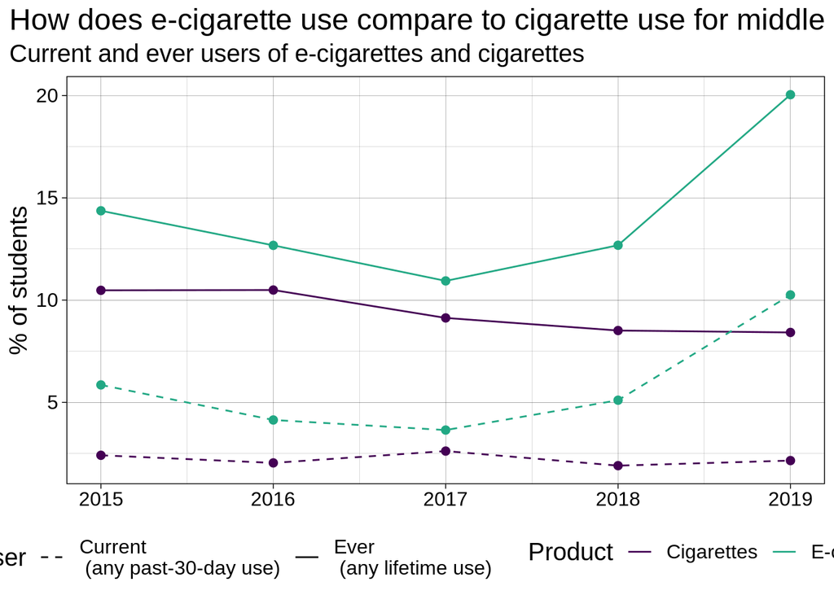

```r
Middle_School
```

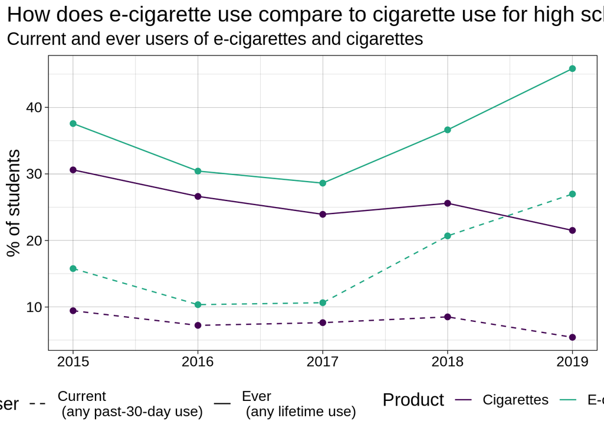

```r
High_School
```

Middle school and high school students follow similar trends as when the data was combined. The main difference between middle school and high school students is that high school students are much more likely to currently use and have ever used e-cigarettes and tobacco. Any lifetime use for middle school students is around 15-20% for e-cigarettes and about 10% for cigarettes while for high school students it’s around 30-45% for e-cigarettes and 20-30% for cigarettes. Just how the percentage is amplified from middle school to high school students, the trends are amplified, which is why high school students have a much higher range of percent of students using across the years.

### Data Analysis

Our data is not always consistent. Given the fact that our data comes from a survey. This means that the data can be unreliable. Not everyone that received a survey responded, meaning the data might not be representative of all people since it only sampled from the specific people that responded to the survey. In this case, we could have over-sampled or under-sampled from individual groups. As a result, we can recalculate our values using survey weights provided in our dataset. The dataset provides us with three variables: ‘psu’, ‘stratum’, and ‘finwgt’. These variables are used to recalculate our values. We will recalculate values for tobacco and e-cigarette use.

```r
#function to tobacco usage using survey weights
surveyMeanA <- function(currYear) {
  options(survey.lonely.psu = "adjust")
  currYear |>
    #creates object to determine the survey design
    as_survey_design(strata = stratum,
                     ids = psu,
                     weight  = finwgt,
                     nest = TRUE) |>
    #recalculates by taking into account the survey weights
    summarize(tobacco_ever = survey_mean(tobacco_ever,
                                         vartype = "ci",
                                         na.rm = TRUE),
              tobacco_current = survey_mean(tobacco_current,
                                            vartype = "ci",
                                            na.rm = TRUE))  |>
    #converting them to percentages
    mutate_all("*", 100) |>
    #obtaining the upper and lower bounds of our outputs
    pivot_longer(everything(),
                 names_to = "Type",
                 values_to = "Percentage of students") |>
    mutate(Estimate = case_when(str_detect(Type, "_low") ~ "Lower",
                                str_detect(Type, "_upp") ~ "Upper",
                                TRUE ~ "Mean"),
           User = case_when(str_detect(Type, "ever") ~ "Ever",
                            str_detect(Type, "current") ~ "Current",
                            TRUE ~ "Mean"))
}

#function to e-cig usage using survey weights
surveyMeanB <- function(currYear) {
  options(survey.lonely.psu = "adjust")
  currYear |>
    #creates object to determine the survey design
    as_survey_design(strata = stratum,
                     ids = psu,
                     weight  = finwgt,
                     nest = TRUE) |>
    #recalculates by taking into account the survey weights
    summarize(ecig_ever = survey_mean(ecig_ever,
                                         vartype = "ci",
                                         na.rm = TRUE),
              ecig_current = survey_mean(ecig_current,
                                            vartype = "ci",
                                            na.rm = TRUE))  |>
    #converting them to percentages
    mutate_all("*", 100) |>
    #obtaining the upper and lower bounds of our outputs
    pivot_longer(everything(),
                 names_to = "Type",
                 values_to = "Percentage of students") |>
    mutate(Estimate = case_when(str_detect(Type, "_low") ~ "Lower",
                                str_detect(Type, "_upp") ~ "Upper",
                                TRUE ~ "Mean"),
           User = case_when(str_detect(Type, "ever") ~ "Ever",
                            str_detect(Type, "current") ~ "Current",
                            TRUE ~ "Mean"))
  }
```

Using the function we created above, we recalculate the values for tobacco usage and plot them with confidence intervals on where the actual value should be around..

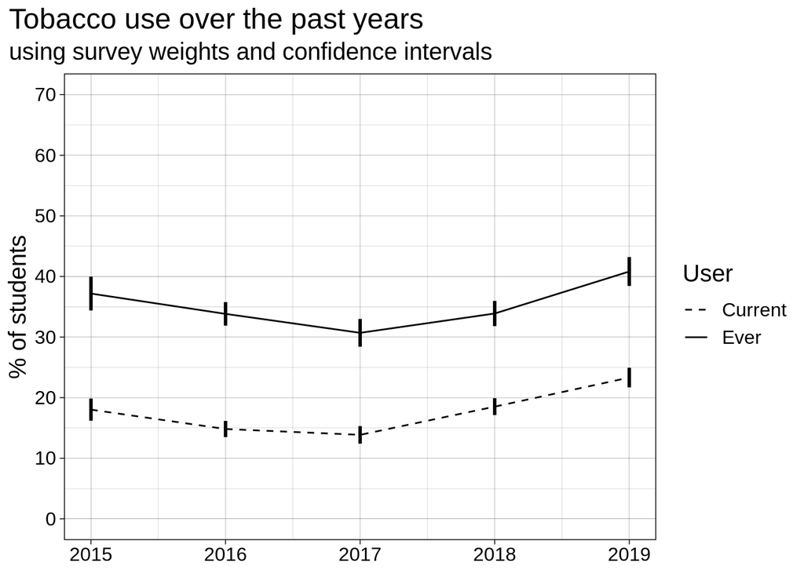

```r
nyts_data |>
  group_by(year) |>
  group_modify(~ surveyMeanA(.x)) |>
  dplyr::select(-Type) |>
  pivot_wider(names_from = Estimate,
             values_from = `Percentage of students`) |>
  ggplot(aes(x = year, y = Mean)) +
  geom_line(aes(linetype = User)) +
  geom_linerange(aes(ymin = Lower,
                     ymax = Upper),
                     size = 1,
              show.legend = FALSE) +
  scale_linetype_manual(values = c(2, 1)) +
  scale_y_continuous(breaks = seq(0, 70, by = 10),
                     labels = seq(0, 70, by = 10),
                     limits = c(0, 70)) +
    theme_linedraw() +
    labs(title = "Tobacco use over the past years",
         subtitle = "using survey weights and confidence intervals",
         y = "% of students") +
    theme(legend.position = "right",
          axis.title.x = element_blank(),
          text = element_text(size = 15),
          plot.title.position = "plot")
```

We see that both lines are very similar to the plot that we provided earlier without the survey weights. The trend still remains that tobacco usage gained more traction after 2017. There might be slight variation with the values themselves if we consider the confidence intervals.

Similar to above, we recalculate the values for e-cigarettes this time and plot them with their respective confidence intervals.

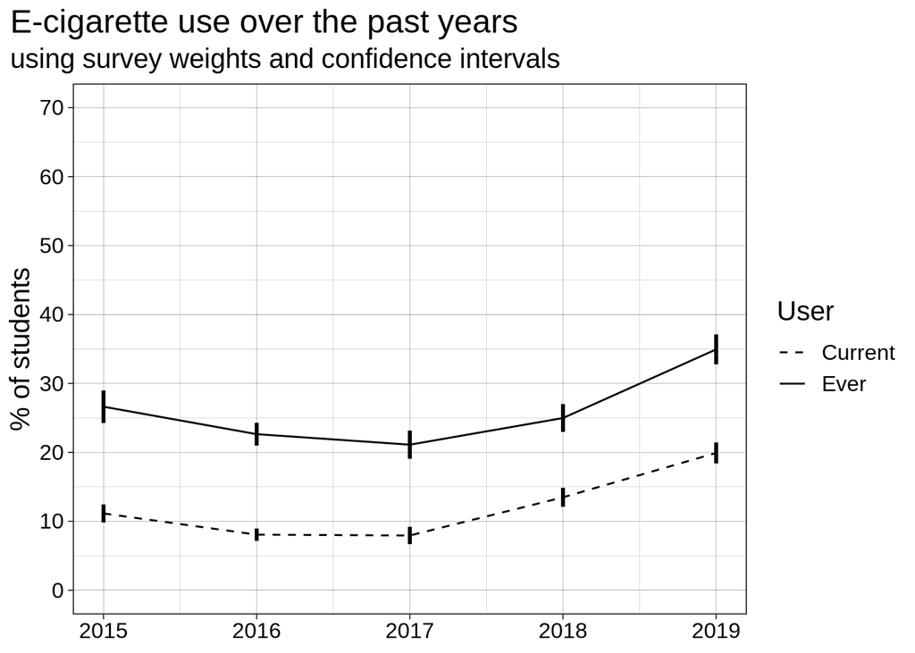

```r
nyts_data |>
  group_by(year) |>
  group_modify(~ surveyMeanB(.x)) |>
  dplyr::select(-Type) |>
  pivot_wider(names_from = Estimate,
             values_from = `Percentage of students`) |>
  ggplot(aes(x = year, y = Mean)) +
  geom_line(aes(linetype = User)) +
  geom_linerange(aes(ymin = Lower,
                     ymax = Upper),
                     size = 1,
              show.legend = FALSE) +
  scale_linetype_manual(values = c(2, 1)) +
  scale_y_continuous(breaks = seq(0, 70, by = 10),
                     labels = seq(0, 70, by = 10),
                     limits = c(0, 70)) +
    theme_linedraw() +
    labs(title = "E-cigarette use over the past years",
         subtitle = "using survey weights and confidence intervals",
         y = "% of students") +
    theme(legend.position = "right",
          axis.title.x = element_blank(),
          text = element_text(size = 15),
          plot.title.position = "plot")
```

Similar to the previous graph, we see that the trend still remains even after we added the survey weights. On the other hand, we can see that the confidence interval for the current e-cigarette users are much smaller, which might indicate that the values might have an accurate representation. However, on the lifetime usage, we see that in 2015 and 2019 the confidence intervals are slightly larger than the rest. In 2019, there were the most lifetime users, ranging from 32% to 37% of students using e-cigarettes.

To determine how e-cigarette use compares between males and females, we fit a logistic regression model across our entire data set, predicting the probability of males and females being current e-cigarette users during 2015-2019. Doing this, we can compare current e-cigarette use and determine what gender is more likely to use currently e-cigarettes.

```r
reg <- nyts_data |>
  filter(!is.na(Sex)) # Filter out NA values for sex
# Create logistic regression model
currEcigSex <- logistic_reg() |>
  set_engine("glm") |>
  fit(as.factor(ecig_current) ~ Sex, data = reg, family = "binomial") # Model current e-cigarette use on gender
currEcigSexTidy <- tidy(currEcigSex)
# Adjust logistic regression model with survey weighting
reg_survey_design <- reg |>
                          as_survey_design(strata = stratum,
                                            ids = psu,
                                            weight  = finwgt,
                                            nest = TRUE)
currEcigSex_svy <- survey::svyglm(ecig_current ~ Sex,
                                  family = quasibinomial(link = 'logit'),
                                  design = reg_survey_design)
tidy(currEcigSex_svy) # Print result
```

```
## # A tibble: 2 × 5
##   term        estimate std.error statistic   p.value
##   <chr>          <dbl>     <dbl>     <dbl>     <dbl>
## 1 (Intercept)   -1.89     0.0355    -53.2  2.58e-187
## 2 Sexfemale     -0.202    0.0278     -7.27 1.85e- 12
```

From this, we see that the log odds of a female being a current e-cigarette user in 2015-2019 on average is .202 lower than males. Thus, the odds are .817 times the odds of males, or 18.3% lower for females.

We performed a similar logistic regression for any lifetime e-cigarette use.

```r
reg <- nyts_data |>
  filter(!is.na(Sex)) # Filter out NA values for sex
# Create logistic regression model
everEcigSex <- logistic_reg() |>
  set_engine("glm") |>
  fit(as.factor(ecig_ever) ~ Sex, data = reg, family = "binomial") # Model ever e-cigarette use on gender
everEcigSexTidy <- tidy(everEcigSex)
# Adjust logistic regression model with survey weighting
reg_survey_design <- reg |>
                          as_survey_design(strata = stratum,
                                            ids = psu,
                                            weight  = finwgt,
                                            nest = TRUE)
everEcigSex_svy <- survey::svyglm(ecig_ever ~ Sex,
                                  family = quasibinomial(link = 'logit'),
                                  design = reg_survey_design)
tidy(everEcigSex_svy) # Print result
```

```
## # A tibble: 2 × 5
##   term        estimate std.error statistic   p.value
##   <chr>          <dbl>     <dbl>     <dbl>     <dbl>
## 1 (Intercept)   -0.974    0.0301    -32.4  1.13e-115
## 2 Sexfemale     -0.139    0.0247     -5.64 3.18e-  8
```

We find similar results in that the log odds of a female having ever used e-cigarettes in 2015-2019 on average is .139 lower than males. Thus, the odds are .870 times the odds of males, or 13.0% lower for females.

Wondering if our results change if we segment by class level, we redid both logistic regressions for current and any lifetime e-cigarette use by gender to incorporate those factors.

```r
reg <- nyts_data |>
  filter(!is.na(Sex), level == "Middle School") # Filter out NA values for sex and select middle schoolers
# Create logistic regression model
currEcigSex <- logistic_reg() |>
  set_engine("glm") |>
  fit(as.factor(ecig_current) ~ Sex, data = reg, family = "binomial") # Model current e-cigarette use on gender
currEcigSexTidy <- tidy(currEcigSex)
# Adjust logistic regression model with survey weighting
reg_survey_design <- reg |>
                          as_survey_design(strata = stratum,
                                            ids = psu,
                                            weight  = finwgt,
                                            nest = TRUE)
currEcigSex_svy <- survey::svyglm(ecig_current ~ Sex,
                                  family = quasibinomial(link = 'logit'),
                                  design = reg_survey_design)
Current_Middle_School = tidy(currEcigSex_svy)

reg <- nyts_data |>
  filter(!is.na(Sex), level == "High School") # Filter out NA values for sex and select high schoolers
# Create logistic regression model
currEcigSex <- logistic_reg() |>
  set_engine("glm") |>
  fit(as.factor(ecig_current) ~ Sex, data = reg, family = "binomial") # Model current e-cigarette use on gender
currEcigSexTidy <- tidy(currEcigSex)
# Adjust logistic regression model with survey weighting
reg_survey_design <- reg |>
                          as_survey_design(strata = stratum,
                                            ids = psu,
                                            weight  = finwgt,
                                            nest = TRUE)
currEcigSex_svy <- survey::svyglm(ecig_current ~ Sex,
                                  family = quasibinomial(link = 'logit'),
                                  design = reg_survey_design)
Current_High_School = tidy(currEcigSex_svy)
```

```r
Current_Middle_School
```

```
## # A tibble: 2 × 5
##   term        estimate std.error statistic   p.value
##   <chr>          <dbl>     <dbl>     <dbl>     <dbl>
## 1 (Intercept)   -2.77     0.0504    -54.9  1.39e-182
## 2 Sexfemale     -0.120    0.0538     -2.23 2.64e-  2
```

```r
Current_High_School
```

```
## # A tibble: 2 × 5
##   term        estimate std.error statistic   p.value
##   <chr>          <dbl>     <dbl>     <dbl>     <dbl>
## 1 (Intercept)   -1.46     0.0399    -36.6  5.30e-122
## 2 Sexfemale     -0.240    0.0339     -7.07 8.13e- 12
```

We see that the log odds of a middle school female being a current e-cigarette user in 2015-2019 on average is .120 lower than males. Thus, the odds are .887 times the odds of males, or 11.3%, lower for females. For a high school female, the log odds are on average .240 lower. Thus the odds are .787 times the odds of males, or 21.3%, lower for females. We can observe that females in middle school are less likely to be current e-cigarette users than males but that margin is lower than it is for high school females and males.

We repeated this analysis for any lifetime usage of e-cigarettes among high school students by gender.

```r
reg <- nyts_data |>
  filter(!is.na(Sex), level == "Middle School") # Filter out NA values for sex and select middle schoolers
# Create logistic regression model
everEcigSex <- logistic_reg() |>
  set_engine("glm") |>
  fit(as.factor(ecig_ever) ~ Sex, data = reg, family = "binomial") # Model ever e-cigarette use on gender
everEcigSexTidy <- tidy(everEcigSex)
# Adjust logistic regression model with survey weighting
reg_survey_design <- reg |>
                          as_survey_design(strata = stratum,
                                            ids = psu,
                                            weight  = finwgt,
                                            nest = TRUE)
everEcigSex_svy <- survey::svyglm(ecig_ever ~ Sex,
                                  family = quasibinomial(link = 'logit'),
                                  design = reg_survey_design)
Ever_Middle_School = tidy(everEcigSex_svy) # Print result

reg <- nyts_data |>
  filter(!is.na(Sex), level == "High School") # Filter out NA values for sex and select high schoolers
# Create logistic regression model
everEcigSex <- logistic_reg() |>
  set_engine("glm") |>
  fit(as.factor(ecig_ever) ~ Sex, data = reg, family = "binomial") # Model ever e-cigarette use on gender
everEcigSexTidy <- tidy(everEcigSex)
# Adjust logistic regression model with survey weighting
reg_survey_design <- reg |>
                          as_survey_design(strata = stratum,
                                            ids = psu,
                                            weight  = finwgt,
                                            nest = TRUE)
everEcigSex_svy <- survey::svyglm(ecig_ever ~ Sex,
                                  family = quasibinomial(link = 'logit'),
                                  design = reg_survey_design)
Ever_High_School = tidy(everEcigSex_svy) # Print result
```

```r
Ever_Middle_School
```

```
## # A tibble: 2 × 5
##   term        estimate std.error statistic   p.value
##   <chr>          <dbl>     <dbl>     <dbl>     <dbl>
## 1 (Intercept)   -1.78     0.0350    -50.8  3.92e-171
## 2 Sexfemale     -0.152    0.0332     -4.57 6.49e-  6
```

```r
Ever_High_School
```

```
## # A tibble: 2 × 5
##   term        estimate std.error statistic  p.value
##   <chr>          <dbl>     <dbl>     <dbl>    <dbl>
## 1 (Intercept)   -0.506    0.0345    -14.7  2.76e-38
## 2 Sexfemale     -0.153    0.0316     -4.84 1.95e- 6
```

To determine whether there is a relationship between e-cigarette use and tobacco use, we first created a logistic regression model predicting current tobacco use given current e-cigarette use.

```r
currTobaEcig <- logistic_reg() |>
  set_engine("glm") |>
  fit(as.factor(tobacco_current) ~ as.factor(ecig_current), data = nyts_data, family = "binomial") # Model current tobacco use on current e-cig use
currTobaEcigTidy <- tidy(currTobaEcig)
# Adjust logistic regression model with survey weighting
currTobaEcig_survey_design <- nyts_data |>
                          as_survey_design(strata = stratum,
                                            ids = psu,
                                            weight  = finwgt,
                                            nest = TRUE)
currTobaEcig_svy <- survey::svyglm(tobacco_current ~ ecig_current,
                                  family = quasibinomial(link = 'logit'),
                                  design = currTobaEcig_survey_design)
tidy(currTobaEcig_svy) # Print result
```

```
## # A tibble: 2 × 5
##   term             estimate std.error statistic   p.value
##   <chr>               <dbl>     <dbl>     <dbl>     <dbl>
## 1 (Intercept)         -2.69    0.0365     -73.7 1.48e-240
## 2 ecig_currentTRUE    21.3     0.0522     409.  0
```

From this, we see that the log odds of a student being a current tobacco user in 2015-2019 on average is 21.3 higher if they current use e-cigarettes, meaning the odds of currently using tobacco is much higher if a student currently e-cigarettes.

We created a similar logistic regression model predicting any lifetime tobacco use given any lifetime e-cigarette use.

```r
everTobaEcig <- logistic_reg() |>
  set_engine("glm") |>
  fit(as.factor(tobacco_ever) ~ as.factor(ecig_ever), data = nyts_data, family = "binomial") # Model current tobacco use on current e-cig use
everTobaEcigTidy <- tidy(everTobaEcig)
# Adjust logistic regression model with survey weighting
everTobaEcig_survey_design <- nyts_data |>
                          as_survey_design(strata = stratum,
                                            ids = psu,
                                            weight  = finwgt,
                                            nest = TRUE)
everTobaEcig_svy <- survey::svyglm(tobacco_ever ~ ecig_ever,
                                  family = quasibinomial(link = 'logit'),
                                  design = currTobaEcig_survey_design)
tidy(everTobaEcig_svy) # Print result
```

```
## # A tibble: 2 × 5
##   term          estimate std.error statistic   p.value
##   <chr>            <dbl>     <dbl>     <dbl>     <dbl>
## 1 (Intercept)      -1.95    0.0317     -61.4 2.12e-210
## 2 ecig_everTRUE    21.6     0.0429     503.  0
```